# BT4212 HW2

Search Engine Optimization and Analytics

## Submission Instructions

There are two ways to submit this assignment.

1. Rmarkdown. (1) RMD file, and make sure the code is executable. An RMD file template is provided. (2) The PDF file generated from your R markdown.
2. Choose the programming language that you are comfortable with to solve these problems. Submit one PDF document with questions and answers and put all source code in the appendix. Your result should be reproducible.

Rmarkdown approach is recommended but not required.

## Introduction to R Markdown

First download R (https://www.r-project.org/) and RStudio (https://rstudio.com/products/rstudio/download/). There is a very active R community online You could find plenty of tutorials about R and Rmarkdown online. For example, this video teaches some basics about R and Rstudio (https://www.youtube.com/watch?v=_V8eKsto3Ug). The following is a very brief introduction to RMarkdown.

You can open R Markdown documents in RStudio. You should see a command called “Knit”, which allows you to “knit” the entire R Markdown file into a HTML document, or a PDF document, or a MS Word Document (note that for PDF, Tex distribution is needed; for MS Word, MS Word needs to be installed on your system).

R Markdown is handy because it allows you to embed code and writeup into the same document, and it produces presentable output, so you can use it to generate reports from your homework, and, when you eventually go out to work in a company, for your projects.

Here’s how you embed a “chunk” of R code.

```r
1+1
```

```
## [1] 2
```

After the three apostrophes, you’ll need `r`, then you can give the chunk a name. Please note that **names have to be single-word and no space is allowed**. Also, names have to be unique, that is, every chunk needs a **different** name. You can give chunks names like:

- `chunk1`
- `read-in-data`
- `run-regression`

Or, those that help you with homework:

- `q1a-read-in-data`
- `q1b-regression`

These names are for you to help organize your code. (In practice it will be very useful when you have files with thousands of lines of code…). After the name of the chunk, you can give it certain options, separated by commas. I will highlight one important option.

- `echo=TRUE` means the code chunk will be copied into the output file. For homework purposes, **always** set `echo=TRUE` so we know what code you wrote. When you go out to work in a company and you want to produce professional-looking reports, feel free to set it to FALSE.

There is a bit more syntax to learn using the R Markdown, but we don’t need you to be an expert in R Markdown (although we do expect proficiency in R!). Hopefully, you can copy all the R Markdown syntax you need from the templates we provide.

Note about **working directory** in R Markdown. If you do not specify your working directory via `setwd('...')`, and you hit “Knit”, the document will assume that the working directory is the directory that the `.rmd` file is in. Thus, if your rmd is in `XYZ/folder1/code.rmd` and your dataset is `XYZ/folder1/data.csv`, then you can simply run `d0 = read.csv('data.csv')` without running `setwd()`.

## Problem 1. Short-Answer Questions (40’)

Throughout the problem, assume that the Stable Unit Treatment Value Assumption (SUTVA) holds true. Refer to thee slides of Lecture 4 or Rubin’s book Chapter 1, if you find yourself unfamiliar with the concept. Following the convention of the notation in potential outcome framework, subscript 0 stands for the control group, and 1 stands for the treatment group.

1. Explain the meaning of $Y_i(0)$ and $Y_i(1)$ and why it is difficult to infer causality. (10’) $Y_i(0)$ is the potential outcome for unit i without treatment, whereas $Y_i(1)$ is the potential outcome for unit i with treatment. In other words, they are the potential outcomes of individual i if they did not receive the treatment (for $Y_i(0)$) and if they did receive the treatment (for $Y_i(1)$). In the Potential Outcome Model, $Y^{obs}_{i} = D_iY_i(1) + (1-D_i)Y_i(0)$ With $D_i$ being 1 if the treatment is administered to that particular individual, whereas $D_i$ is 0 when it isn’t. In such a model, when $D_i$ is 1, $Y_i(0)$ ceases to exist, as $(1-D_i)$ = 0, and vice versa. Thus only one component, either $Y_i(1)$ or $Y_i(0)$ can exist in the observed outcome of subject i. It is difficult to infer causality as $Y_i(0)$ and $Y_i(1)$ are counterfactuals of each other. If one is to exist, the other would not. Thus, not being able to observe $Y_i(1)$ and $Y_i(0)$ for the same individual i. This results in a missing data problem, where any treatent administered to one individual, it’s counterfactual will be missing, thus being impossible to identify ti without further assumptions (where $ti = Y_i(1) - Y_i(0)$). Being unable to compare the $Y_i(1)$ and $Y_i(0)$ of a singular individual, we cannot observe the causal effect for that individual. In order to assume causality, certain assumptions of the potential outcome model must be adhered to. This includes:
1. Assuming potential outcomes are constant across individuals, resulting in cross-individual comparison being able to recover the individual causal effect
2. Assuming potential outcomes are constant across time, then the before-after comparison is able to recover the individual causal effect ti.

Since individual causal effects are fundamentally unobservable, we would have to adhere to those assumptions in order to attain the average causal effect in a population. Thus making it difficult to infer causality.

2. Explain the meaning of $Y^{obs}_{i}$. (5’) $Y^{obs}_{i}$ is the observed outcome of an individual subject, subject i. In practice, this will be the outcome that we see in the data collected. This is in conjunction with knowing whether the individual has received the treatment or not.
3. Explain the meaning of $\mathbb{E}[Y_i(0)|D_i=1]$, where a binary variable $D_i= 1$ if treated, 0 if untreated. (5’) That is the expected value of the potential outcome of the individual when untreated, $Y_i(0)$, given that a treatment is administered to the individual. In other words, it is the counterfactual expectation value, as it represents what would have occurred if the individual was untreated instead of the them currently being treated.
4. Contrast the meaning of $\mathbb{E}[Y^{obs}_i|D_i = 1]$ with the meaning of $\mathbb{E}[Y_i(0)|D_i=1]$ and explain the meaning of their difference, i.e., $\mathbb{E}[Y^{obs}_i|D_i = 1] - \mathbb{E}[Y_i(0)|D_i=1]$. (10’) $\mathbb{E}[Y^{obs}_i|D_i = 1]$ refers to the expected value of the observed outcome of the individual, $Y^{obs}_i$, given that the treatment has been administered. Whereas the meaning of $\mathbb{E}[Y_i(0)|D_i=1]$ is the expected value of the potential outcome of the individual when untreated, $Y_i(0)$, given that a treatment is administered to the individual as explained in c). As shown in the potential outcome model equation, $Y^{obs}_{i} = D_iY_i(1) + (1-D_i)Y_i(0)$, when $D_i = 1$, $Y^{obs}_i$ is equivalent to $Y_i$, making the difference $\mathbb{E}[Y^{obs}_i|D_i = 1] - \mathbb{E}[Y_i(0)|D_i=1]$ to be equivalent to $\mathbb{E}[Y_i(1)|D_i = 1] - \mathbb{E}[Y_i(0)|D_i=1]$. Such difference between the expected outcome of an individual who had been administered the treatment and it’s counterfactual is the average treatment effect on the treated as the counterfactual expectation is unobservable.
5. Following part (d), please contrast the meaning of $\mathbb{E}[Y_i(1)-Y_i(0)|D_i=1]$ with $\mathbb{E}[Y_i(1) - Y_i(0)]$ and explain how randomized experiment helps to relate these two quantities. (10’) $\mathbb{E}[Y_i(1)-Y_i(0)|D_i=1]$ is the average treatment effect on the treated (ATT) as it is the difference between the expected outcome of an individual who had been administered the treatment and it’s counterfactual, as explained in d). $\mathbb{E}[Y_i(1) - Y_i(0)]$ on the other hand, is the Average treatment effect (ATE) on the particular individual. The ATE cannot be observed as in the Fundamental Problem of Causal Inference, we cannot observe both $Y_i(0)$ and $Y_i(1)$ for the same i. This is in contrast with the ATT which can be observed, as it is the average treatment effect between the treated and untreated after the treatment has been administered, thus including the condition of the treatment being administered, now making the expression estimatable through statistical methods. Randomized Experiments can help relate these quantities by ensuring that each potential outcome is independent from one another, leading to no interference between units or spill-over effects, adhering to the SUTVA assumptions. Randomization also ensures that the treatment and control groups are statistically equivalent on observed and unobserved characteristics, leading to no systematic differences between them other than the treatment itself. This random assignment makes it easier to estimate both ATT and ATE without bias. For ATE, it allows us to compare average outcomes between treatment and control group, and as the groups are comparable, the observed difference in outcomes can be attributed to the treatment effect, thus able to estimate ATE. For ATT, the difference in outcomes for the treated individuals compared to what they would have experienced without treatment can be inferred through randomization as it controls for selection bias. Overall if the treatment effects are constant across everyone, then ATT == ATE.

## Problem 2. A/B Test on Webpage Design (60’)

1. Please load the input data and print the first 6 rows of the data. The data contains two columns with one being the observed daily clicks and the other being the treatment status. (5’)

```r
set.seed(1) # please fix the random seed.

# your code here
data <- read.csv("expdta-click.csv")
head(data)
```

|  | X | dailyclick | treatment |
| --- | --- | --- | --- |
| 1 | 1 | 9861 | 0 |
| 2 | 2 | 8851 | 0 |
| 3 | 3 | 9673 | 1 |
| 4 | 4 | 7974 | 1 |
| 5 | 5 | 9512 | 0 |
| 6 | 6 | 9711 | 1 |

2. You believe that by splitting the download buttons help to boost the click-through rate. Let $Y_i$ denote the daily click and $D_i \in \{0,1\}$ be the treatment assignment for day $i = 1, 2,\ldots, 20$. You are considering a claim: “Version 1 of the web design increases the daily clicks by 2000, compared to the version 0 for all Internet traffic”.

The null hypothesis could be easily formulated as:
$$H_0: Y_i(1) = Y_i(0) + 2000$$

Based on the null hypothesis $H_0$, what **would** be the table that describes the potential outcomes for all subjects in this experiment? Please print out the table.  
(Hint: there should be 4 columns: 1st column displays the observed daily clicks; 2nd column displays the treatment status; 3rd column displays the $Y_i(1)$ under $H_0$; 4th column displays the $Y_i(0)$ under $H_0$). (6’)

Since $Y_i$ si the daily click,

```r
# Extracting first 20 Daily Clicks and Treatments
observed_daily_clicks <- data$dailyclick[1:20]
treatment_status <- data$treatment[1:20]

# Formulating H0_Yi(0) and H0_Yi(1)
H0_Y0 <- ifelse(treatment_status == 0, observed_daily_clicks, observed_daily_clicks - 2000)
H0_Y1 <- ifelse(treatment_status == 1, observed_daily_clicks, observed_daily_clicks + 2000)
result <- data.frame(observed_daily_clicks, treatment_status, H0_Y1, H0_Y0)
knitr::kable(result, caption="Potential Outcomes for all subjects")
```

Potential Outcomes for all subjects

| observed_daily_clicks | treatment_status | H0_Y1 | H0_Y0 |
| --- | --- | --- | --- |
| 9861 | 0 | 11861 | 9861 |
| 8851 | 0 | 10851 | 8851 |
| 9673 | 1 | 9673 | 7673 |
| 7974 | 1 | 7974 | 5974 |
| 9512 | 0 | 11512 | 9512 |
| 9711 | 1 | 9711 | 7711 |
| 9749 | 1 | 9749 | 7749 |
| 10814 | 1 | 10814 | 8814 |
| 11399 | 1 | 11399 | 9399 |
| 9035 | 0 | 11035 | 9035 |
| 9327 | 0 | 11327 | 9327 |
| 9204 | 0 | 11204 | 9204 |
| 10485 | 1 | 10485 | 8485 |
| 6710 | 0 | 8710 | 6710 |
| 10145 | 1 | 10145 | 8145 |
| 8449 | 0 | 10449 | 8449 |
| 10079 | 1 | 10079 | 8079 |
| 9137 | 1 | 9137 | 7137 |
| 8070 | 0 | 10070 | 8070 |
| 10905 | 1 | 10905 | 8905 |

3. Let the test statistics be $T=\bar{Y}^{obs}_1-\bar{Y}^{obs}_0-2000$. Simulate the exact probability distribution of this test statistic $T$ under $H_0$ in a completely randomized experiment with equal number of subjects in each group. Please report (1) the total number of realizations of the randomized assignment vector, (2) the quartiles 25%, 50%, 75% of the distribution of the test statistic $T$, and (3) the standard deviation. (10’) Hint: Please read about **exact null hypothesis** or Fisher-Sharp null hypothesis. You could find the relevant discussion in Rubin’s book [RI] sec 1-4, ch.5. You could install and load the library `gtools` and use the function `combinations` to help generate realizations of the randomized assignment vector. See: https://www.rdocumentation.org/packages/gtools/versions/3.9.3/topics/combinations).

```r
library(gtools)
num_of_instances <- nrow(result)
num_of_treatment <- sum(result$treatment_status)
combs <- combinations(num_of_instances, num_of_treatment)

# 1) Total number of realizations
total_realizations <- nrow(combs)
total_realizations
```

```
## [1] 167960
```

```r
T_values <- numeric(total_realizations)
# Thus number of realizations is 167960

# Computing distribution to attain quartiles
distri <- apply(combs, 1, function(x) {
  repe <- rep(0, num_of_instances)
  repe[x] <- 1
  mean(H0_Y1[repe == 1]) - mean(H0_Y0[repe == 0]) - 2000
})

# 2) Computing Quartiles and SD
# Quartiles
quartiles <- c(0.25, 0.50, 0.75)
quantiles <- quantile(distri, probs = quartiles)
quantiles
```

```
##         25%         50%         75%
## -315.050505   -3.131313  313.030303
```

```r
# For 25th Quartile: -315.050505; For 50th Quartile: -3.131313; For 75th Quartile: 313.030303

# 3) Standard deviation
standard_deviation <- sd(distri)
standard_deviation
```

```
## [1] 448.4832
```

```r
# The Standard Deviation is 448.4832
```

4. Plot the histogram of this test statistic $T$ with `breaks = 50`. For more information about plotting a histogram. Refer to https://www.datamentor.io/r-programming/histogram/. (5’)

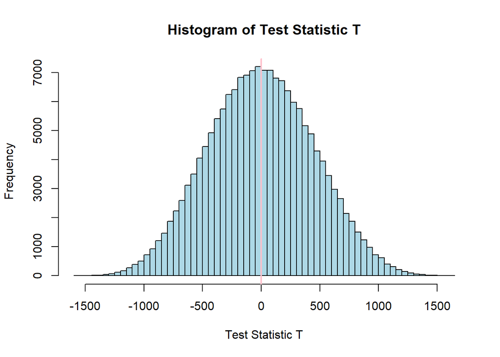

```r
# Plot the histogram with breaks = 50
histo <- hist(distri, breaks = 50, main = "Histogram of Test Statistic T",
     xlab = "Test Statistic T", col = "lightblue", border = "black")

# Mean Line
abline(v = mean(distri), col = "pink", lwd = 2)
```